# Lab 4

Author

Katherine

Question 1:

```r
if (!file.exists("met_all.gz"))
  download.file(
    url = "https://raw.githubusercontent.com/USCbiostats/data-science-data/master/02_met/met_all.gz",
    destfile = "met_all.gz",
    method   = "libcurl",
    timeout  = 60
    )
met <- data.table::fread("met_all.gz")
```

Question 2

```r
library(data.table)
library(lubridate)
library(tidyverse)
met<-met[temp> -17][elev==9999.0, elev :=NA]
met[, week := week(as.Date(paste(year, month, day, sep ="-")))]
met <- met[week == min(week, na.rm = TRUE)]
```

```r
library(data.table)

met_avg <- met[
  ,
  .(
    temp      = mean(temp,      na.rm = TRUE),
    rh        = mean(rh,        na.rm = TRUE),
    wind.sp   = mean(wind.sp,   na.rm = TRUE),
    vis.dist  = mean(vis.dist,  na.rm = TRUE),
    dew.point = mean(dew.point, na.rm = TRUE),
    lat       = mean(lat,       na.rm = TRUE),
    lon       = mean(lon,       na.rm = TRUE),
    elev      = mean(elev,      na.rm = TRUE)
  ),
  by = USAFID
]
```

```r
met_avg$region <- ifelse(met_avg$lon > -98 & met_avg$lat >39.71, "north east",
                         ifelse(met_avg$lon > -98 &
                                  met_avg$lat <39.71, "south east",
                                ifelse(met_avg$lon < -98 &met_avg$lat >39.71,
                                       "north west", "south west")))
met_avg$elev_cat <- ifelse(met_avg$elev> 252, "high", "low")
table(met_avg$region)
```

```
north east north west south east south west
       484        146        649        296
```

Question 3:

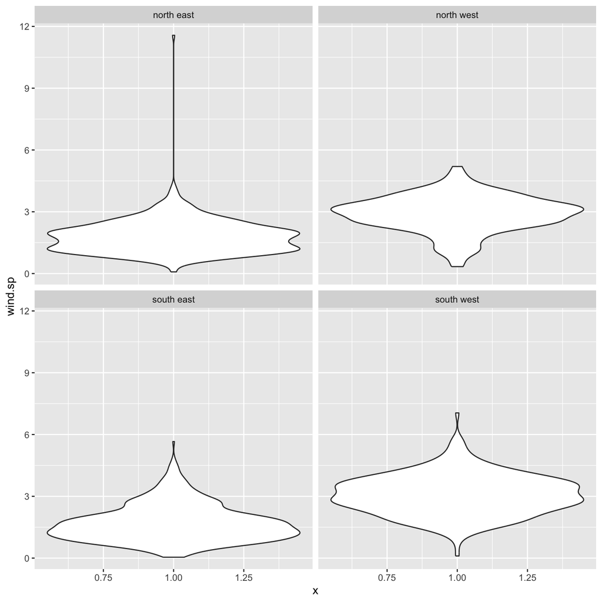

```r
met_avg %>%
  filter(!(wind.sp %in% NA)) %>%
ggplot()+
  geom_violin (mapping = aes(y=wind.sp, x=1))+
  facet_wrap(~region,nrow = 2)
```

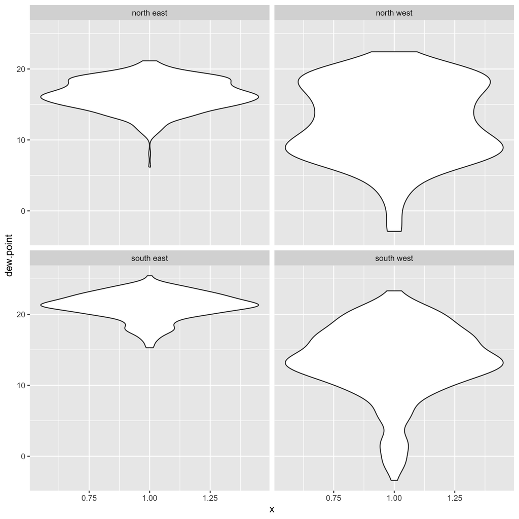

```r
met_avg %>%
  filter(!(dew.point %in% NA)) %>%
ggplot()+
  geom_violin (mapping = aes(y=dew.point, x=1))+
  facet_wrap(~region,nrow = 2)
```

**Description** **From this graph, we can see that southeast region has the highest humid all above 15 dew points, and southwest hasroader spread. For northeast, the humid is also high, which is interesting that both east has high humid, and northwest is lowest median and widest range, which are like southwest.**

Question 4

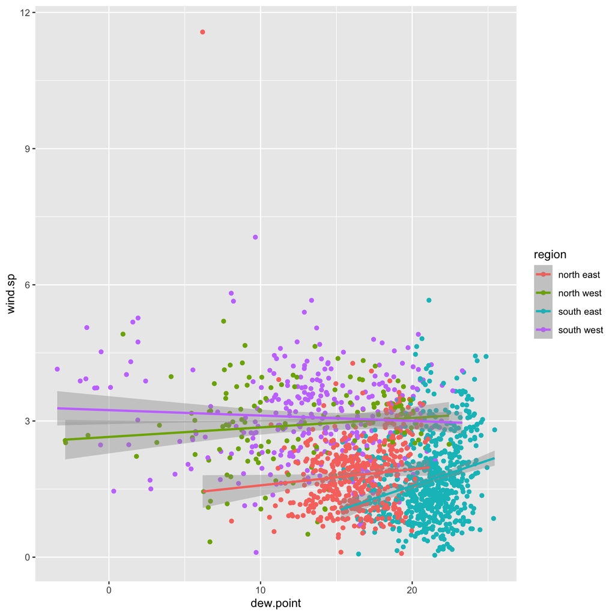

```r
met_avg %>%
  filter(!is.na(dew.point) &!is.na(wind.sp) %in% NA) %>%
ggplot(mapping = aes(x=dew.point,y=wind.sp, color=region))+
  geom_jitter()+
  stat_smooth(method = lm)
```

**Description** **For southwest, the slope the flat to slight negative. Southeast, the slope it positive, suggesting that wind speed increase while dew point increase For northwest and northeast, they both have positve slopes, but not as positive as southeast.**

Question 5

```
Ignoring unknown labels:
• titles : "Number of weather stations by elevation catergory and region"
```

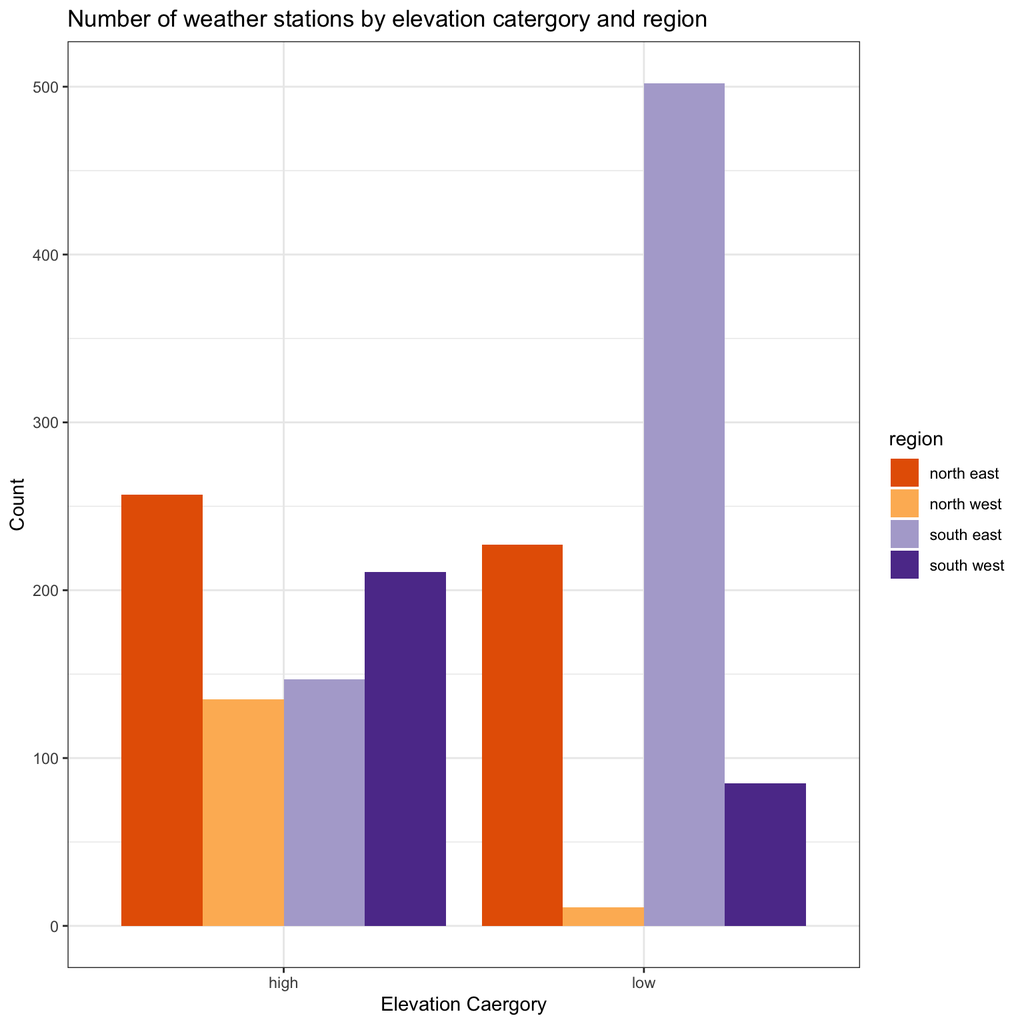

```r
met_avg %>%
  filter(!(elev_cat %in% NA)) %>%
           ggplot()+
           geom_bar(mapping = aes(x=elev_cat, fill = region), position = "dodge")+
           scale_fill_brewer(palette = "PuOr")+
           labs(titles="Number of weather stations by elevation catergory and region",
                x="Elevation Caergory", y="Count")+
         theme_bw()
```

**Description** **The low is dominated by southeast, and northwest has very few as well as southwest. High elevation are more balanced.**

Question 6

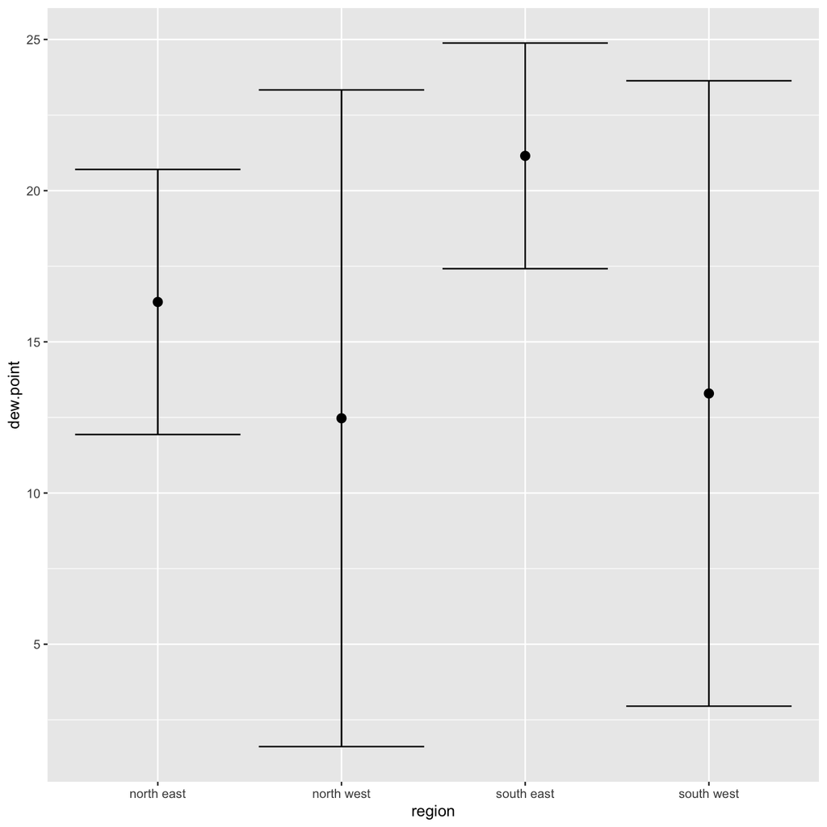

```r
met_avg %>%
  filter(!is.na(dew.point) &!is.na(wind.sp) %in% NA) %>%
  ggplot(mapping = aes(x=region,y=dew.point))+
  stat_summary(fun.data = "mean_sdl", geom = "errorbar")+
  stat_summary(fun.data = "mean_sdl")
```

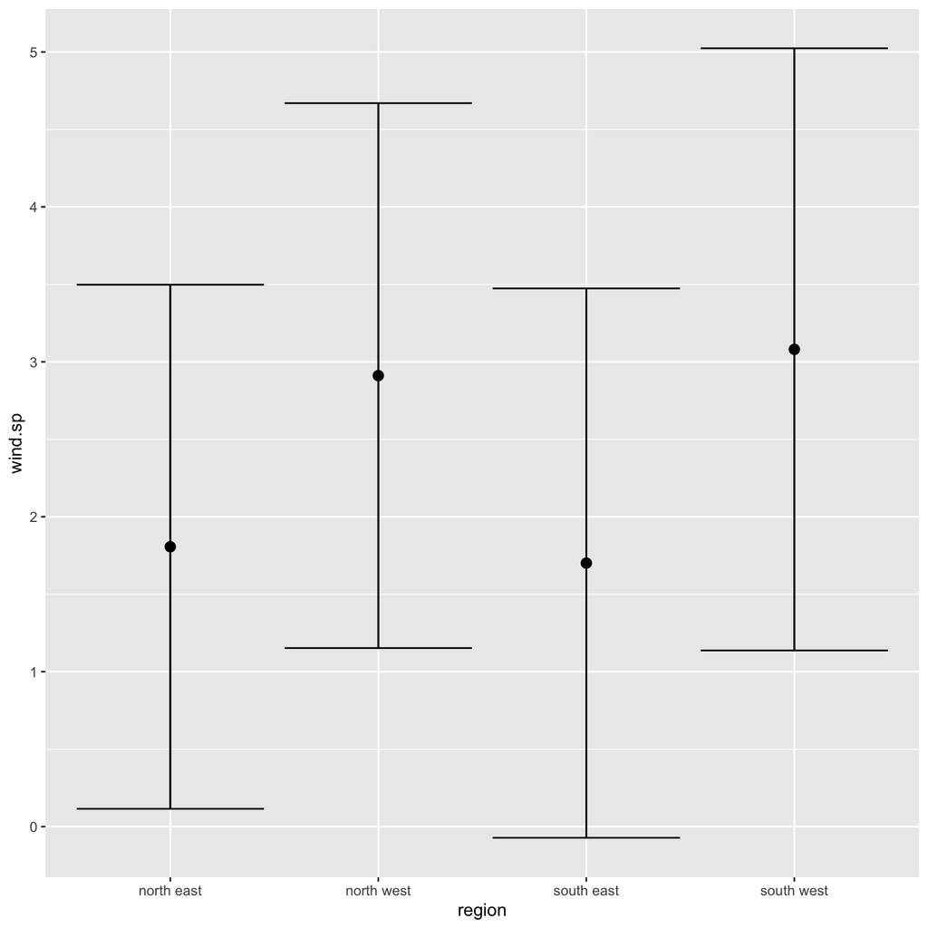

```r
met_avg %>%
  filter(!is.na(dew.point) &!is.na(wind.sp) %in% NA) %>%
  ggplot(mapping = aes(x=region,y=wind.sp))+
  stat_summary(fun.data = "mean_sdl", geom = "errorbar")+
  stat_summary(fun.data = "mean_sdl")
```

**Description** **The graphs shows that South West has the highest winds on average (~3 m/s) and the widest range (min around ~1 m/s, max ~5 m/s). North West has next highest mean (~3 m/s) with a fairly large spread (roughly ~1.1 to ~4.6 m/s). North East has lower mean (~1.8 m/s) and a narrower range (about ~0.1 to ~3.5 m/s). South East has lowest mean (~1.7 m/s) and includes near-calm lows (≈0), upper range ~3.5 m/s.**

Question 7

```r
library(dplyr)
library(leaflet)

met_avg2 <- met_avg[!is.na(rh)]
top10 <- met_avg2[rank(-rh)]
rh_pal = colorNumeric(c('blue', 'purple', 'red'), domain=met_avg2$rh)



leaflet(met_avg2) %>%
  addProviderTiles("OpenStreetMap") %>%
  addCircles(
    lat = ~lat, lng = ~lon,
    color = ~rh_pal(rh), fillColor = ~rh_pal(rh),
    opacity = 1, fillOpacity = 0.8, radius = 500,
    label = ~paste0(round(rh, 2), "% RH")
  ) %>%
  addMarkers(
    data = top10,
    lat = ~lat, lng = ~lon,
    label = ~paste0(round(rh, 2), "%")
  ) %>%
  addLegend("bottomleft", pal = rh_pal, values = ~rh,
            title = "Relative Humidity (%)", opacity = 1)
```

[interactive chart not shown]

**Description** **From the interactive map, we can see that the humidity is lower in place like Los Angles and Las Vegas. This is the case probably do to its dessert landscape condition.**

Question 8

```r
library(ggplot2)
library(gganimate)
library(gifski)
library(dplyr)

# data: your averaged table `met_avg`
df <- met_avg %>%
  filter(is.finite(dew.point), is.finite(wind.sp), !is.na(region)) %>%
  mutate(region = droplevels(factor(region)))

p_reg <- ggplot(df, aes(dew.point, wind.sp, colour = region)) +
  geom_point(alpha = 0.7, size = 1.6, show.legend = TRUE) +
  labs(title = "Region: {closest_state}",
       x = "Dew point (°C)", y = "Wind speed (m/s)") +
  transition_states(region, transition_length = 0.6, state_length = 1) +
  ease_aes("sine-in-out")

dir.create("figs", showWarnings = FALSE)
a <- animate(p_reg, renderer = gifski_renderer(),
             nframes = 40, fps = 12, width = 640, height = 360, progress = FALSE)
anim_save("figs/dew-wind_by-region.gif", animation = a)

#| label: show-dew-wind-gif
#| echo: false
knitr::include_graphics("figs/dew-wind_by-region.gif")
```

[output not shown]